# How to hand in an assignment on Quercus

## Navigate to the course assignment page

First, [log in to Quercus](https://q.utoronto.ca) and find your course.

Down the left side (on the white, not on the blue), you’ll see Assignments. Click it. You should see a list of Assignments, something like this:

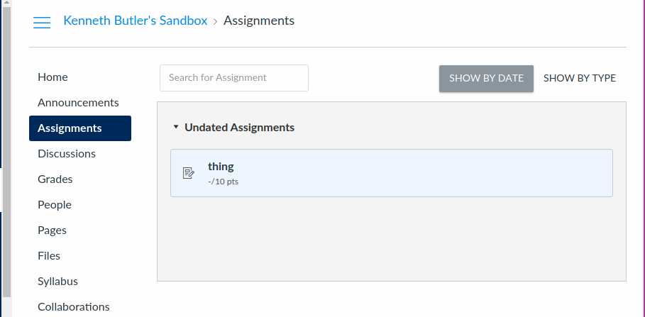

Yours will probably display Upcoming Assignments rather than Undated Assignments, and top left will be the course code rather than the text you see here. Note that the assignment here called Thing is out of 10 points, but there is no grade for it (because it hasn’t been graded yet, because you haven’t handed it in yet!)

Click the title of the assignment you want to hand in. Here that would be “thing”.

## The page for the assignment you want to hand in

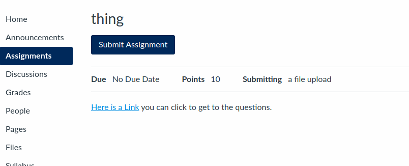

There might be some text saying what the assignment is about, or, as here, there might be a link that you can click to get to the assignment questions. Above that will be displayed the due date (if any), the number of points a perfect assignment will score, and what you have to submit. In this case, I’m asking you to upload a file from your computer. Click the big blue Submit Assignment.

## Uploading the file

In this course, I expect you to submit something like the HTML file obtained by Previewing an R Notebook, which I am assuming you have downloaded. Here’s where we are at now:

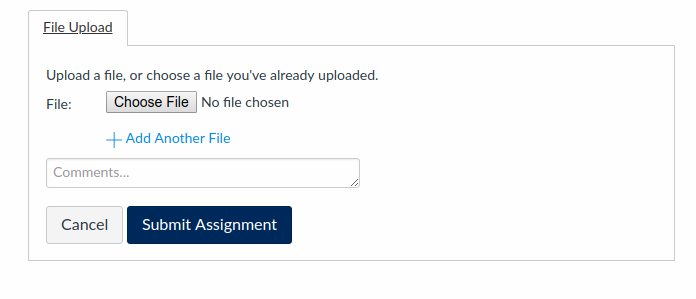

Click on Choose File and find the file that you want to submit:

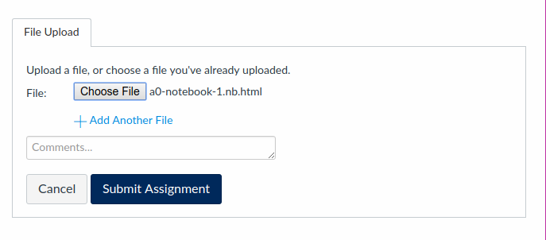

The file you uploaded appears next to Choose File. You should try to organize things so that the whole assignment is in *one* file, but if you need to submit more than one file, click Add Another File and choose it in the same way. When you are happy that you have uploaded all your files, click Submit Assignment. You’ll see something like this:

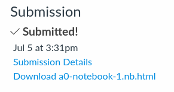

and then you know that your assignment was properly submitted.

It appears to be either difficult or impossible to un-submit an assignment, so be careful about submitting files. If you did submit the wrong thing, use “re-submit assignment” to make another submission *of the whole thing*. I instruct graders that the *last* submission is the one that will be graded.

## Later

When the assignment has been graded, you can go back to the Assignments page and see that you now have a mark for it:

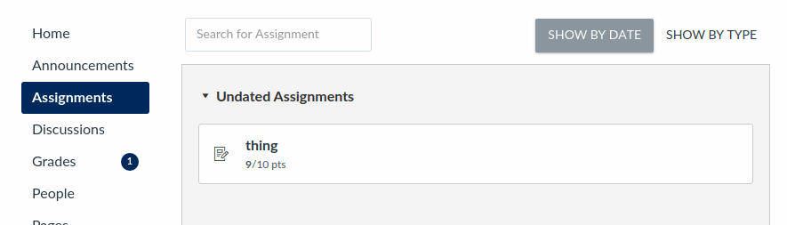

or click on Grades to get more detail:

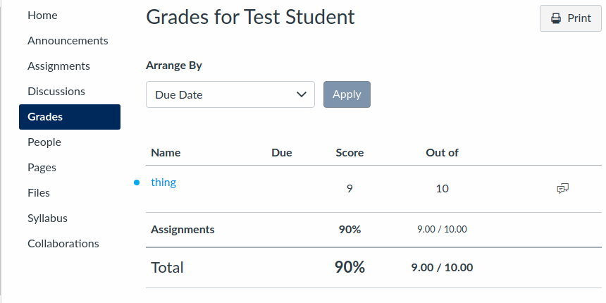

Last, you can click on the “speech bubbles” to the right of the Score and Out Of to see any comments the grader made:

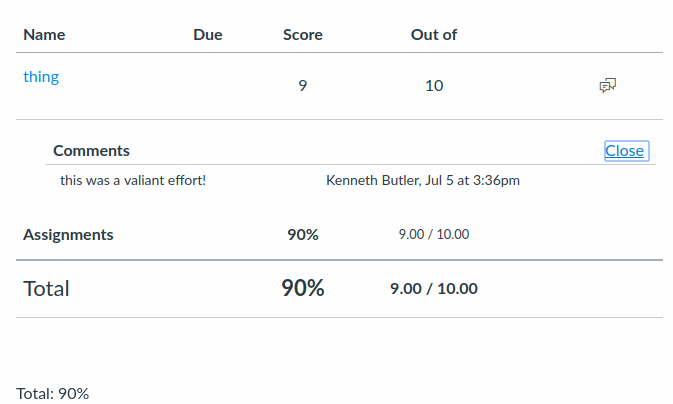